# jan13.Rmd

Rajesh

January 13, 2017

getting the data and loading it into R

```r
if(!file.exists("data")){dir.create("data")}
fileurl <- "https://d396qusza40orc.cloudfront.net/repdata%2Fdata%2Factivity.zip"
download.file(fileurl,destfile = "./data.zip",method="auto")
unzip(zipfile = "./data.zip")
data1 <- read.csv("./activity.csv",header = T,colClasses = c("integer", "character", "integer"),na.strings="NA")
library(markdown)
```

```r
library(lubridate)
data1$date <- ymd(data1$date)
dim(data1)
```

```
## [1] 17568     3
```

```r
names(data1)
```

```
## [1] "steps"    "date"     "interval"
```

```r
head(data1)
```

```
##   steps       date interval
## 1    NA 2012-10-01        0
## 2    NA 2012-10-01        5
## 3    NA 2012-10-01       10
## 4    NA 2012-10-01       15
## 5    NA 2012-10-01       20
## 6    NA 2012-10-01       25
```

## Including Plots

### plot for ‘Histogram of the total number of steps taken each day’

```r
library(dplyr)
everydaysteps <- data1 %>%
  filter(!is.na(steps)) %>%
  group_by(date) %>%
  summarize(steps = sum(steps)) %>%
  print
```

```
## # A tibble: 53 × 2
##          date steps
##        <date> <int>
## 1  2012-10-02   126
## 2  2012-10-03 11352
## 3  2012-10-04 12116
## 4  2012-10-05 13294
## 5  2012-10-06 15420
## 6  2012-10-07 11015
## 7  2012-10-09 12811
## 8  2012-10-10  9900
## 9  2012-10-11 10304
## 10 2012-10-12 17382
## # ... with 43 more rows
```

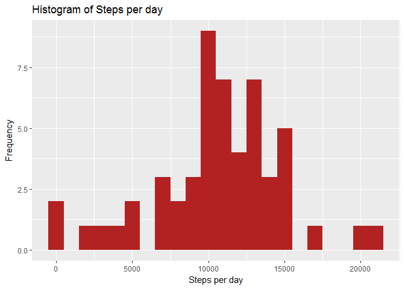

```r
library(ggplot2)
ggplot(everydaysteps, aes(x = steps)) +
  geom_histogram(fill = "firebrick", binwidth = 1000) +
  labs(title = "Histogram of Steps per day", x = "Steps per day", y = "Frequency")
```

### Mean and median number of steps taken each day

```r
mean(everydaysteps$steps, na.rm=TRUE)
```

```
## [1] 10766.19
```

```r
median(everydaysteps$steps, na.rm=TRUE)
```

```
## [1] 10765
```

### Time series plot of the average number of steps taken

find the average number of steps for each 5 minute

```r
intervalsteps <- aggregate(steps ~ interval, data1,na.rm=T, mean)
names(intervalsteps)
```

```
## [1] "interval" "steps"
```

```r
names(intervalsteps)[2]
```

```
## [1] "steps"
```

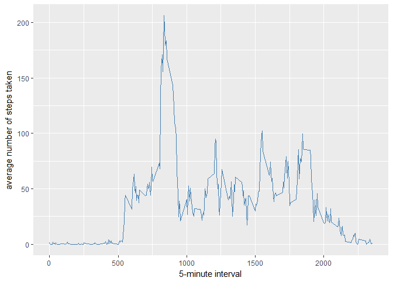

```r
names(intervalsteps)[2] <- "average_steps"##changing the column name
g <- ggplot(intervalsteps,aes(interval,average_steps))
g+geom_line(col = "steelblue")+labs(x= "5-minute interval")+labs(y = "average number of steps taken")
```

###The 5-minute interval that, on average, contains the maximum number of steps

```r
intervalsteps[which.max(intervalsteps$average_steps),]
```

```
##     interval average_steps
## 104      835      206.1698
```

### Code to describe and show a strategy for imputing missing dat

to know how many missing values

```r
missing <- is.na(data1$steps)
table(missing)
```

```
## missing
## FALSE  TRUE
## 15264  2304
```

### Histogram of the total number of steps taken each day after missing values are imputed

first,create the new dataset with NA filled

```r
imputeddata <- merge(data1, intervalsteps, by = 'interval', all.y = F)
imputeddata$steps[is.na(imputeddata$steps)] <- as.integer(
        round(imputeddata$average_steps[is.na(imputeddata$steps)]))
keeps <- names(data1)
imputeddata <- imputeddata[keeps]
```

next,plot the histogram

```r
neweverydaysteps <- aggregate(steps ~ date, imputeddata, sum)##to plot the histogram,we need to find total number of steps##
head(neweverydaysteps)
```

```
##         date steps
## 1 2012-10-01 10762
## 2 2012-10-02   126
## 3 2012-10-03 11352
## 4 2012-10-04 12116
## 5 2012-10-05 13294
## 6 2012-10-06 15420
```

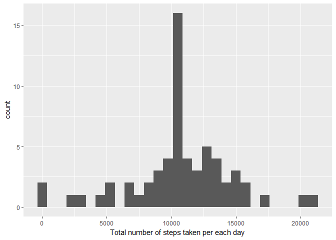

```r
names(neweverydaysteps)[2] <- "sum_steps"
qplot(sum_steps,data = neweverydaysteps,binwidth = 750,xlab = "Total number of steps taken per each day")
```

```r
mean(neweverydaysteps$sum_steps)
```

```
## [1] 10765.64
```

```r
median(neweverydaysteps$sum_steps)
```

```
## [1] 10762
```

The impact of imputing missing data on the estimates of the total daily number of steps is also clear: now we have higher frquency counts in the histogram at the center region (close to the mean).

### Panel plot comparing the average number of steps taken per 5-minute interval across weekdays and weekends

first,Create a new factor variable in the dataset with two levels - “weekday” and “weekend’

```r
newdata <- imputeddata##create the new dataframe
weekend <- weekdays(as.Date(newdata$date)) %in% c("Saturday", "Sunday")
newdata$daytype <- "weekday"##fill in weekday column
newdata$daytype[weekend == TRUE] <- "weekend"##replace the weekday column with weekend where daytype ==sat/sun
newdata$daytype <- as.factor(newdata$daytype)##convert to factor variable
dim(newdata)##check the dimensions of the newdata
```

```
## [1] 17568     4
```

```r
str(newdata)
```

```
## 'data.frame':    17568 obs. of  4 variables:
##  $ steps   : int  2 0 0 0 0 0 0 0 0 0 ...
##  $ date    : Date, format: "2012-10-01" "2012-11-23" ...
##  $ interval: int  0 0 0 0 0 0 0 0 0 0 ...
##  $ daytype : Factor w/ 2 levels "weekday","weekend": 1 1 2 1 2 1 2 1 1 2 ...
```

```r
head(newdata)
```

```
##   steps       date interval daytype
## 1     2 2012-10-01        0 weekday
## 2     0 2012-11-23        0 weekday
## 3     0 2012-10-28        0 weekend
## 4     0 2012-11-06        0 weekday
## 5     0 2012-11-24        0 weekend
## 6     0 2012-11-15        0 weekday
```

```r
class(newdata$daytype)##double check
```

```
## [1] "factor"
```

Make the panel plot

```r
newinterval <- aggregate(steps ~ interval + daytype, newdata, mean)
head(newinterval)
```

```
##   interval daytype      steps
## 1        0 weekday 2.28888889
## 2        5 weekday 0.40000000
## 3       10 weekday 0.15555556
## 4       15 weekday 0.17777778
## 5       20 weekday 0.08888889
## 6       25 weekday 1.57777778
```

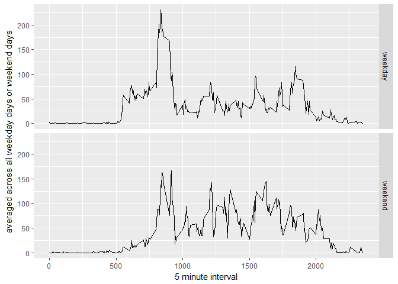

```r
 names(newinterval)[3] <- "mean_steps"##change the column name
qplot(interval,mean_steps,data=newinterval,facets = daytype~.,geom = "path", xlab = "5 minute interval",ylab ="averaged across all weekday days or weekend days")
```